# Random Variables & Probability Functions

2022-09-15

# Previously… (1/2)

**Independence**

**[PSDR] Definition 2.20**

Two events are said to be *independent* if knowledge that one event occurs does not give any probabilistic information as to whether the other event occurs. Formally, we say that $A$ and $B$ are independent if $P(A \cap B) = P(A)P(B)$.

Events $A$ and $B$ are said to be dependent if they are not independent.

**Conditional Probability**

**[PSDR] Definition 2.18**

Let $A$ and $B$ be events in the sample space $S$, with $P(B) \ne 0$. The conditional probability of $A$ given $B$ is
$$P(A|B)
= \frac{P(A \cap B)}{P(B)}$$

# Previously… (2/2)

**Bayes’ Theorem and The Law of Total Probability**

**[PSDR] Definition 2.30**

We say that $A_1, \cdots, A_k$ is a partition of the sample space $S$ if $\bigcup_{i=1}^k A_i = S$ and $A_i \cap A_j = \emptyset$ whenever $i \ne j$.

**[PSDR] Theorem 2.6**

Let $A_1, \cdots, A_k$ be a partition of the sample space $S$ and let $B$ be an event. Then,

$$P(B) = \sum_{i=i}^k P(B \cap A_i) =
\sum_{i=1}^k P(A_i)P(B|A_i)$$

and

$$P(A_j|B) =
\frac{P(A_j)P(B|A_j)}{\sum_{i=1}^k P(A_i)P(B|A_i)}.$$

In words,

$$\text{posterior} = \frac{\text{prior}
\times \text{likelihood}}{\text{marginalization}}.$$

# Example Problem 1 (1/2)

Consider a scenario where you have only *one* urn with contents *one* black ball and one red.

*You draw one ball.*

- Sample space:

  $$S = \{B,R\}$$
  - Let $X$ be random variable representing drawing a ball, and $x$ be the outcome of drawing a black ball ($x=1$) or red ball ($x=0$);

$P(X = 1) = \frac{1}{2} \longrightarrow$ the probability of drawing black

$P(X = 0) = \frac{1}{2} \longrightarrow$ the probability of drawing red

- Here, $S$ is a **discrete** sample space and $X$ is a **discrete** random variable.

# Example Problem 1 (2/2)

We can model the ball drawing using a **probability function**.

- For one ball draw, we know the **probability function** to be
  $$P(X = x; p) =
  \begin{cases} p & \text{if } x=1 \text{ (B)} \\ 1-p & \text{if }
  x=0 \text{ (R)}\end{cases}$$
  where $p=\frac{1}{2}$ and $X$ is the **discrete random variable** for the outcome of the ball draw to be black or not black (which is red).
- This function is also known as the **Bernoulli Distribution**, a statistical model for only two possible outcomes (yes/no,success/failure,etc.) of any single experiment.
- We can rewrite the above function as
  $$P(X=x; p) = p^x (1-p)^{1-x}$$
- The term $p$ is the parameter of the function, which is the probability of observing a black ball.

# Example Problem 2 (1/3)

*You draw one ball with replacement three times.* Note that each draw are now independent events.

- Sample space:
  $$S =
  \{\{B,B,B\},\{B,B,R\},\{B,R,R\},\{R,R,R\}, \\
  \{R,R,B\},\{R,B,B\},\{B,R,B\},\{R,B,R\}\}$$
- Let the random variable $X$ to be the number of black balls in this scenario;
  $$X = \{x_0,x_1,x_2,x_3\} =
  {0,1,2,3}$$
- *Example probabilities:*
  - $P(X = 3) = 1 \left( \frac{1}{2} \cdot \frac{1}{2} \cdot \frac{1}{2} \right) = \frac{1}{8} \longrightarrow$ the probability of getting **exactly** black balls
  - $P(X = 2) = 3 \left( \frac{1}{2} \cdot \frac{1}{2} \cdot \frac{1}{2} \right) = \frac{3}{8} \longrightarrow$ the probability of getting **exactly** two black balls
  - $P(X \ge 2) = 3 \left( \frac{1}{2} \cdot \frac{1}{2} \cdot \frac{1}{2} \right) + 1 \left( \frac{1}{2} \cdot \frac{1}{2} \cdot \frac{1}{2} \right) = \frac{4}{8} = \frac{1}{2} = \longrightarrow$ the probability of getting **at least** two heads
- Here, $S$ is a **discrete** sample space and $X$ is a **discrete random variable**.

# Example Problem 2 (2/3)

- Let the **discrete random variable** $X$ to be the number of black balls (say observing a black ball is considered as a success). We want to define a **probability function** to compute the probability of observing the number of black balls (observing the number of successes).
- Let $n$ be the number of tosses and $p$ be the probability of success. In this example, $p=\frac{1}{2}$.
- The **probability function** that models multiple ball drawings from an urn - with replacement - is the **Binomial**, which is used when there are exactly two **disjoint** (also called **mutually exclusive**) outcomes of a trial (in this case, a ball draw from an urn with two distinct balls).
- These outcomes are labeled “success” (observing heads) and “failure” (observing not heads - which tails).

# Example Problem 2 (3/3)

- The general form of the **Binomial** Probability Function is given by
  $$P(X = x; n, p) =
  \binom{n}{x} p^x (1-p)^{(n-x)} \hspace{5px} \text{ for } x =
  0,1,2,\cdots, n$$
  where $\binom{n}{x} = \frac{n!}{x!(n-x)!}$.
- The parameters of this function is $p$ and $n$. The binomial distribution assumes that $p$ is fixed for all $n$ trials.
  - $p$ is the probability of drawing a black ball.
  - $n$ is the number of draws.
- Notice that the term $p^x (1-p)^{(n-x)}$ is the **Bernoulli**. Here, a trial is also called a **Bernoulli trial**, a random experiment with exactly two possible outcomes.

# Drawing a Ball from an Urn $\mathbf{n = 20}$ Times

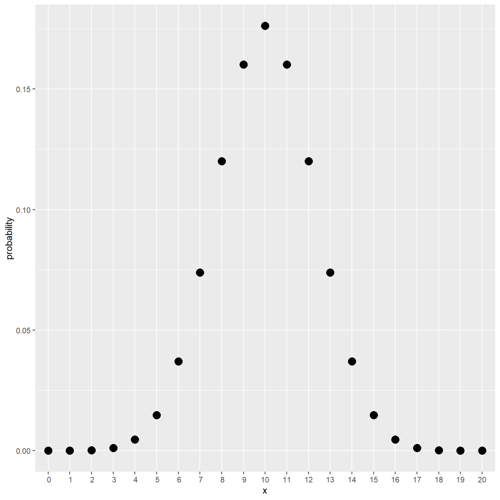

Using the **binomial** probability function, we can answer probability questions much more easily.

# Drawing a Ball $\mathbf{n = 20}$ Times

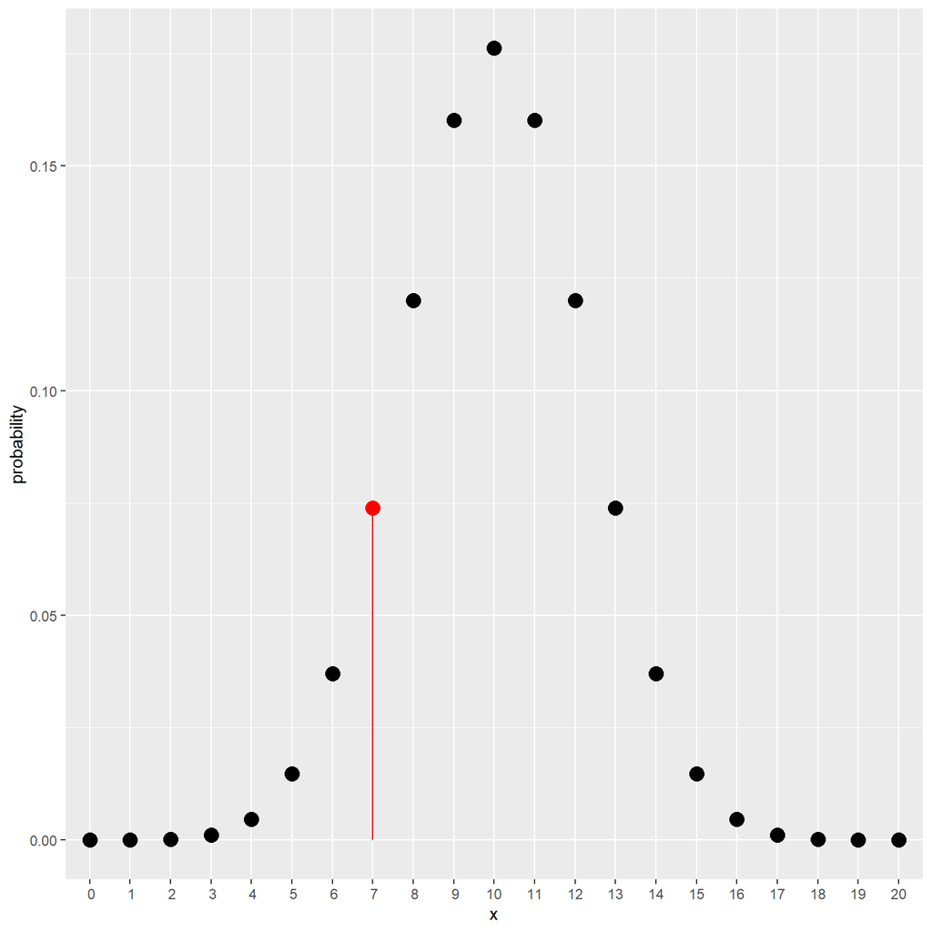

Using the **binomial** probability function, we can answer probability questions much more easily.

The probability of observing **exacty** 7 black balls is
$$P(X = 7) = 0.0739$$

# Drawing a Ball $\mathbf{n = 20}$ Times

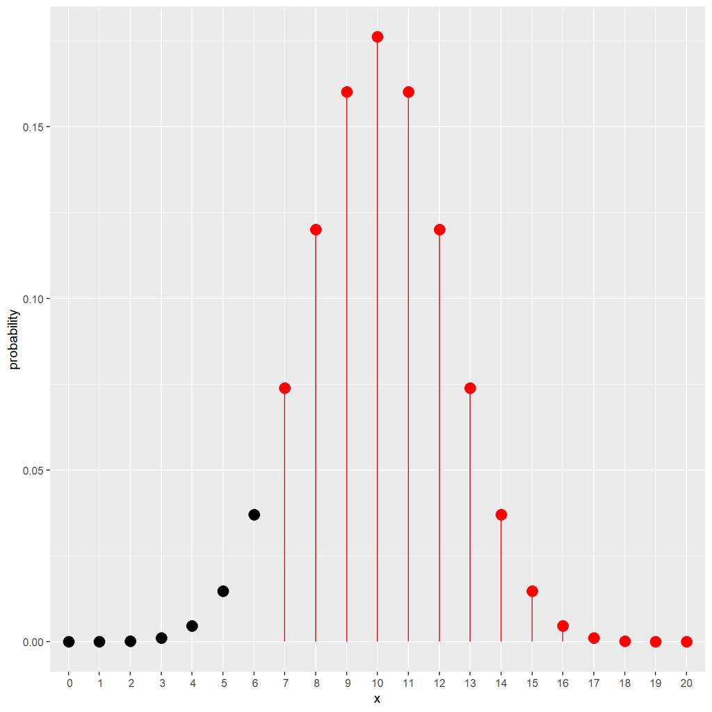

Using the **binomial** probability function, we can answer probability questions much more easily.

The probability of observing **at least** 7 black balls is
$$P(X \ge 7) = \sum_{x=7}^{20} P(X = x) =
0.9423$$

# Discrete versus Continuous Random Variables

- **Discrete Random Variable**: A random variable that can take on only a finite or countably infinite set of outcomes. We can say that a discrete R.V. has distinct values that can be counted.  
  *Example:* Coin Flips, Dice Rolls, Outcomes of a Test (positive/negative), gender (M/F), etc.
- **Continuous Random Variable**: A random variable that can take on any value along a continuum (but may be reported “discretely”)  
  *Example:* Height (really continuous, but we usually just report to the nearest inch/centimeter), temperatures, etc.

# Discrete versus Continuous Probability Functions

- **Probability Functions = Probability Distributions** Table, Graph, or Formula that describes values a random variable can take on, and its corresponding probability (discrete random variable) or density (continuous random variable).
- We call a Probability Function as **Probability Mass Function (PMF)** for *discrete random variables* and **Probability Density Function (PDF)** for *continuous random variables*.

# Mini-Activity

Mini-Assignment: Random Variables and Probability Functions

Back to Tentative Topics Schedule.